# 50183 - Marmot Lake - Analyze capture-mark-recapture data using *mrmr*

Roland Knapp and Thomas Smith

This notebook analyzes capture-mark-recapture data using the *mrmr* package. The code creates the required survey, capture, and translocation data frames from saved CSV files (created by 50183_createdata_mrmr.Rmd), checks the datasets, fits the model, evaluates potential non-convergence of the MCMC algorithm, and visualizes model results.

Before using the code in this file, replace all instances of “xxxxx” with the 5-digit site_id of interest.

## Install latest versions of cmdstanr, cmdstan, and mrmr packages

- Run only if updated versions were released since previous install.

```r
install.packages("cmdstanr", repos = c("https://mc-stan.org/r-packages/", getOption("repos")))
```

```
Error in install.packages : Updating loaded packages
```

## Load required packages

```r
library(dplyr)
library(tidyverse)
library(reshape2)
library(readr)
library(tibble)
library(cmdstanr)
library(mrmr)
library(patchwork)
```

## Create required datasets

- Ignore “translocations” file if translocations/reintroductions are not relevant

| site_id | survey_date | survey_type | primary_period | secondary_period |
| --- | --- | --- | --- | --- |
| 50183 | 2022-09-16 | reintroduction | 1 | 0 |
| 50183 | 2023-09-05 | cmr | 2 | 1 |
| 50183 | 2023-09-06 | cmr | 2 | 2 |
| 50183 | 2023-09-09 | reintroduction | 3 | 0 |
| 50183 | 2023-09-19 | cmr | 4 | 1 |
| 50183 | 2023-09-20 | cmr | 4 | 2 |
| 50183 | 2024-07-29 | cmr | 5 | 1 |
| 50183 | 2024-07-30 | cmr | 5 | 2 |
| 50183 | 2024-07-31 | cmr | 5 | 3 |
| 50183 | 2024-08-01 | reintroduction | 6 | 0 |

[output cut: 7 more lines]

## Fit model

- Code assumes that there are 8 physical cores available. Update parallel_chains and threads_per_chain as necessary based on actual number of cores.
- Add “adapt_delta = 0.99” or similar (after “treats_per_chain”) if divergent transitions occur.

```r
model_50183 <- fit_model(
                    data = data_50183,
                    chains = 4,
                    parallel_chains = 4,
                    cpp_options = list(stan_threads = TRUE),
                    threads_per_chain = 2,
                    adapt_delta = 0.99)
```

```
Running MCMC with 4 parallel chains, with 2 thread(s) per chain...

Chain 1 Iteration:    1 / 2000 [  0%]  (Warmup)
Chain 2 Iteration:    1 / 2000 [  0%]  (Warmup)
Chain 3 Iteration:    1 / 2000 [  0%]  (Warmup)
Chain 4 Iteration:    1 / 2000 [  0%]  (Warmup)
Chain 4 Iteration:  100 / 2000 [  5%]  (Warmup)
Chain 3 Iteration:  100 / 2000 [  5%]  (Warmup)
Chain 2 Iteration:  100 / 2000 [  5%]  (Warmup)
Chain 1 Iteration:  100 / 2000 [  5%]  (Warmup)
Chain 4 Iteration:  200 / 2000 [ 10%]  (Warmup)
Chain 3 Iteration:  200 / 2000 [ 10%]  (Warmup)
Chain 2 Iteration:  200 / 2000 [ 10%]  (Warmup)
Chain 4 Iteration:  300 / 2000 [ 15%]  (Warmup)
Chain 1 Iteration:  200 / 2000 [ 10%]  (Warmup)
Chain 3 Iteration:  300 / 2000 [ 15%]  (Warmup)
Chain 4 Iteration:  400 / 2000 [ 20%]  (Warmup)
Chain 1 Iteration:  300 / 2000 [ 15%]  (Warmup)
Chain 3 Iteration:  400 / 2000 [ 20%]  (Warmup)
Chain 2 Iteration:  300 / 2000 [ 15%]  (Warmup)
Chain 1 Iteration:  400 / 2000 [ 20%]  (Warmup)
Chain 4 Iteration:  500 / 2000 [ 25%]  (Warmup)
Chain 2 Iteration:  400 / 2000 [ 20%]  (Warmup)
Chain 3 Iteration:  500 / 2000 [ 25%]  (Warmup)
Chain 1 Iteration:  500 / 2000 [ 25%]  (Warmup)
Chain 4 Iteration:  600 / 2000 [ 30%]  (Warmup)
Chain 2 Iteration:  500 / 2000 [ 25%]  (Warmup)
Chain 3 Iteration:  600 / 2000 [ 30%]  (Warmup)
Chain 1 Iteration:  600 / 2000 [ 30%]  (Warmup)
Chain 4 Iteration:  700 / 2000 [ 35%]  (Warmup)
Chain 2 Iteration:  600 / 2000 [ 30%]  (Warmup)
Chain 1 Iteration:  700 / 2000 [ 35%]  (Warmup)
Chain 3 Iteration:  700 / 2000 [ 35%]  (Warmup)
Chain 4 Iteration:  800 / 2000 [ 40%]  (Warmup)
Chain 2 Iteration:  700 / 2000 [ 35%]  (Warmup)
Chain 1 Iteration:  800 / 2000 [ 40%]  (Warmup)
Chain 3 Iteration:  800 / 2000 [ 40%]  (Warmup)
Chain 4 Iteration:  900 / 2000 [ 45%]  (Warmup)
Chain 2 Iteration:  800 / 2000 [ 40%]  (Warmup)
Chain 1 Iteration:  900 / 2000 [ 45%]  (Warmup)
```

[output cut: 43 more lines]

```
Chain 3 finished in 923.2 seconds.
Chain 2 Iteration: 1500 / 2000 [ 75%]  (Sampling)
Chain 1 Iteration: 1900 / 2000 [ 95%]  (Sampling)
Chain 2 Iteration: 1600 / 2000 [ 80%]  (Sampling)
Chain 1 Iteration: 2000 / 2000 [100%]  (Sampling)
Chain 1 finished in 989.1 seconds.
Chain 2 Iteration: 1700 / 2000 [ 85%]  (Sampling)
Chain 2 Iteration: 1800 / 2000 [ 90%]  (Sampling)
Chain 2 Iteration: 1900 / 2000 [ 95%]  (Sampling)
Chain 2 Iteration: 2000 / 2000 [100%]  (Sampling)
Chain 2 finished in 1109.2 seconds.

All 4 chains finished successfully.
Mean chain execution time: 972.4 seconds.
Total execution time: 1109.3 seconds.
```

- Running model with default adapt_delta (0.8) resulted in one divergent transition (1/4000).
- Running model with adapt_delta = 0.99 resulted in zero divergent transition (0/4000).

### Save model object

- This step prevents having to rerun the model in the event of a crash during model visualizations in subsequent code chunks.
- Model files can be large, so this saves the file in a compressed format.
- To read model file, use “model_50183 <- read_rds(here::here(”out”, “model”, “50183_model.rds”))”

### Diagnose potential non-convergence of the MCMC algorithm

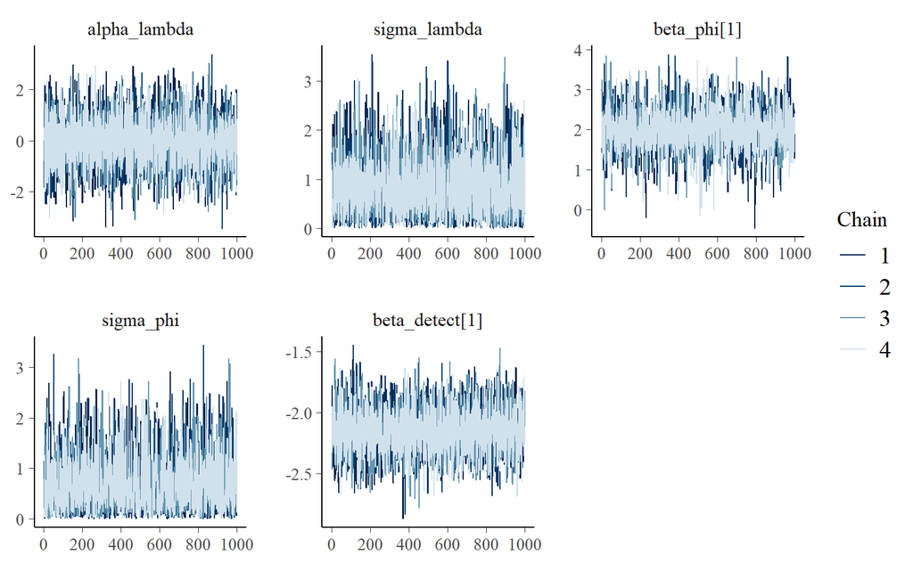

## Visualize model results

### Default plots

- Custom plots (produced in next code chunk: “plots_custom”) are often easier to interpret than the default plots produced by this code chunk.

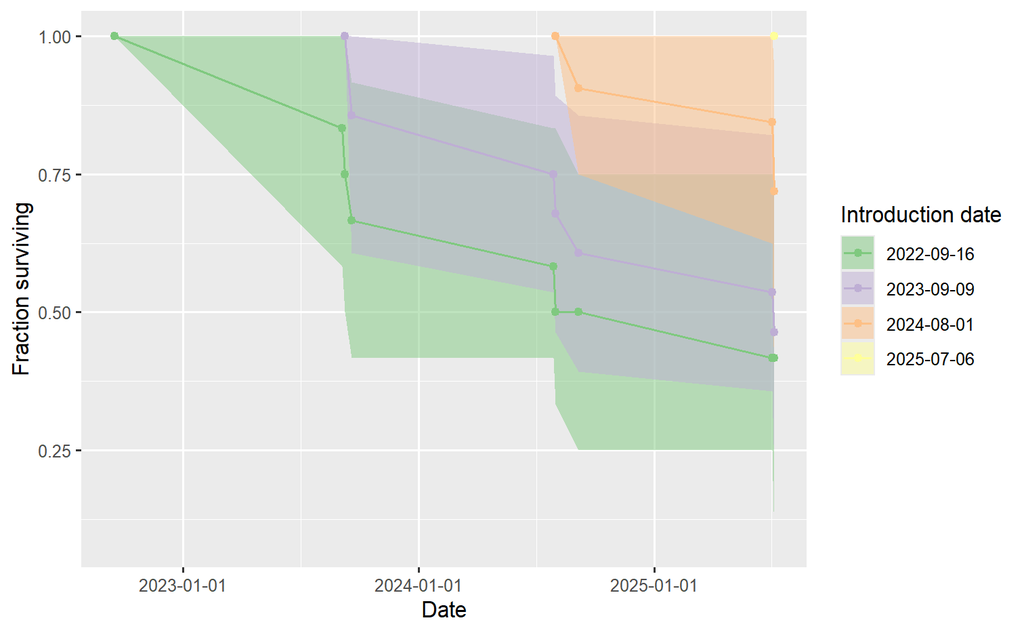

### Custom plots

- Remove p1 if translocations/reintroductions are not relevant.

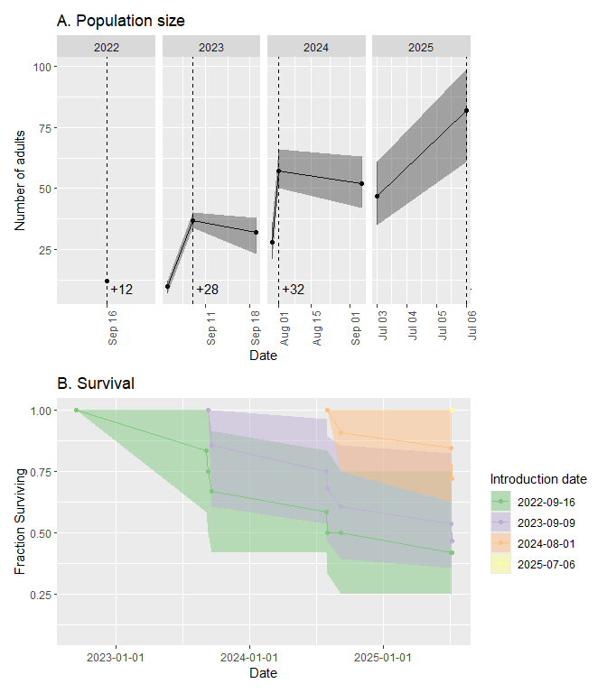

```r
library(ggplot2)
library(patchwork)
p2 <- plot_model(model_50183, what = "abundance")
p2 <- p2 + ggtitle("A. Population size") +
    ylab("Number of adults") # +
    # expand_limits(y = 0)
p3 <- plot_model(model_50183, what = "survival")
p3 <- p3 + ggtitle("B. Survival") +
     ylab("Fraction Surviving") # +
    # expand_limits(y = 0)

p2/p3
```

## Create survival tables

- Calculated for translocated/reintroduced frogs only, so skip if translocations/reintroductions are not relevant.
- Only the cohort-level survival table is displayed because the individual-level survival table can be large.

| years_since_introduction | release_date | lo_survival | median_survival | hi_survival |
| --- | --- | --- | --- | --- |
| 0 | 2023-09-09 | 0.6071429 | 0.8571429 | 1.0000000 |
| 0 | 2024-08-01 | 0.7500000 | 0.9062500 | 1.0000000 |
| 1 | 2022-09-16 | 0.5000000 | 0.7500000 | 0.9444444 |
| 1 | 2023-09-09 | 0.4880952 | 0.6785714 | 0.8928571 |
| 1 | 2024-08-01 | 0.5312500 | 0.7656250 | 0.9531250 |
| 2 | 2022-09-16 | 0.3611111 | 0.5277778 | 0.8333333 |
| 2 | 2023-09-09 | 0.3035714 | 0.5178571 | 0.7857143 |
| 3 | 2022-09-16 | 0.1666667 | 0.4166667 | 0.7500000 |

### Save survival tables

```r
survival_cohort %>% write_csv(here::here("out", "tables", "50183_survival_cohort.csv"))
survival_ind %>% write_csv(here::here("out", "tables", "50183_survival_ind.csv"))
```